# Homework 5: The Mystery Coins

# Homework 5: The Mystery Coins

**Assignment:** Your task is to use Rmarkdown to write a short report, readable by a technically literate person. The code you used should not be visible in the final report (unless you have a good reason to show it).

## The problem.

I have a sizeable collection of old coins, some of strange shapes. (Not really, but imagine.) I have selected 100 of these and flipped each one some number of times: some more, some less. The resulting data is in the file coin_flips.txt, with one row per coin. Each coin has in intrinsic probability, $\theta$, with which it comes up Heads; let’s assume that the distribution of these probabilities across my collection of coins is close to a Beta distribution. This means that the number of Heads in each row of the data file has a [Beta-Binomial distribution](https://en.wikipedia.org/wiki/Beta-binomial_distribution). The overall goal is to infer this distribution of $\theta$ values, i.e., the values of $\alpha$ and $\beta$ in that distribution.

If a given coin has a probability of Heads drawn from a Beta-Binomial($\alpha$, $\beta$) distribution, then (consulting [Wikipedia](https://en.wikipedia.org/wiki/Beta-binomial_distribution)), the likelihood of getting $k$ Heads in $n$ flips is
$$\binom{n}{k}\frac{B(k + \alpha, n - k + \beta)}{B(\alpha, \beta)},$$
where $B(a, b)$ is the Beta function. It’s easier to work with log-likelihoods, and the logarithm of this likelihood can be computed in R as:

```
    lchoose(n, k) + lbeta(k + alpha, n - k + beta) - lbeta(alpha, beta)
```

This is the likelihood for a single coin that was flipped $n$ times getting $k$ heads, to get the likelihood for an entire dataset of coins you need to add up this log-likelihood across all coins.

Your report should:

1. Read in and describe the data, including both numerical and graphical summaries. The functions `strsplit()` and `readLines()` might be helpful.
2. Find the maximum likelihood estimate for the parameters $\alpha$ and $\beta$ of the Beta distribution that describes the distribution of $\theta$ across coins. To do this, you should make a plot of the likelihood surface by evaluating the log-likelihood across a grid of values of $\alpha$ and $\beta$, and then plotting these as an image or a contour surface. You could then find the maximum by hand (looking at the plot!) or with a built-in optimizer (e.g., `optim()`). (You will need to write a function to compute the log-likelihood based on the above.)
3. Make a plot of the Beta distribution with your estimated values of $\alpha$ and $\beta$, and explain what this says about my bag of coins (to make for the reader the idea of a probability distribution of probabilities more concrete).

Be sure to explain what is being done to the best of your ability!

*Note:* Here is example code to make a contour plot, so you know what sort of picture I have in mind for (2). You may of course do this any way you want.

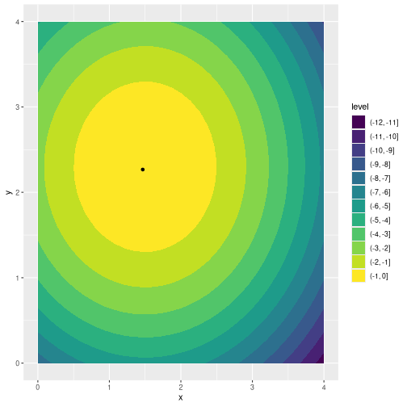

```r
# we'll be plotting a hill with the top at (a, b)
a <- 1.5
b <- 2.3
f <- function (x, y) { - (x - a)^2 - (y - b)^2 }

nx <- 31
xvals <- seq(0, 4, length.out=nx)
yvals <- seq(0, 4, length.out=nx)
xy <- expand.grid(
        x = xvals,
        y = yvals
)
xy$f <- NA
for (j in 1:nrow(xy)) {
    xy$f[j] <- f(xy$x[j], xy$y[j])
}
max_xy <- xy|> slice_max(f)

# option 1
xy |> ggplot(aes(x=x, y=y, z=f)) + geom_contour_filled() +
    annotate("point", x=max_xy$x, y=max_xy$y)
```

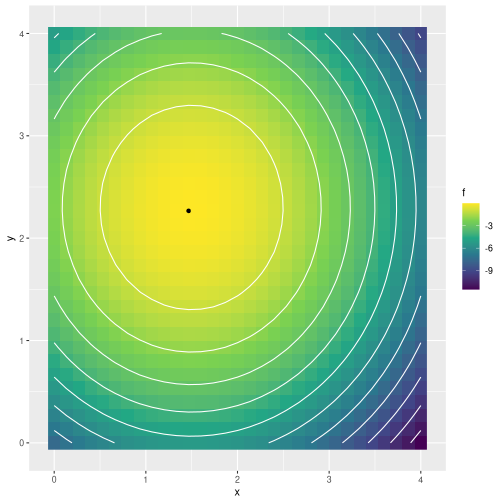

```r
# option 2
xy |> ggplot(aes(x=x, y=y, z=f)) + geom_raster(aes(fill=f)) + geom_contour(color='white') +
    scale_fill_viridis_c() +
    geom_point(data=max_xy)
```